# Introduction

### Scientific Question:

Is the adult mus musculus an appropriate model for analyzing the effects of mutation in the FTO gene in homo sapiens, based on nucleotide sequence and protein structure similarity?

### Background:

The fat mass and obesity-associated protein is also known as the alpha-ketoglutarate-dependent dioxygenase FTO. This was the first gene to be explicitly associated with obesity. Single nucleotide polymorphisms (SNPs) in this gene region are associated with a high body mass index (BMI) and high risk of obesity (Frayling, 2007). Some of the SNPs found in the gene have also been linked to various types of cancer (Loos and Yeo, 2014).

In their efforts to study the effects of the FTO gene in Humans (Homo Sapiens), many reaserachers have utilized mice (Mus Musculus). Mice have been used as the model organisms for studying a variety of FTO-related effects in humans. These include, but are not limited to, metabolic effects of point mutations in the FTO gene (Church, 2009) and FTO's effects on papillary thyroid cancer (Huang, 2022).

While the FTO gene is found in both humans and mice, research has not been conducted to compare their similairties and differences. This is extremely important in determining if the effects of single nucleotide polymorphisms will be the same in both organsims. If the gene is not similar between the organisms, mice may not be the best model to use for research regarding the human FTO gene.

##### Sources:

Church, Chris et al. “A mouse model for the metabolic effects of the human fat mass and obesity associated FTO gene.” PLoS genetics vol. 5,8 (2009): e1000599.

Frayling, Timothy M., et al. "A common variant in the FTO gene is associated with body mass index and predisposes to childhood and adult obesity." Science 316.5826 (2007): 889-894.

Huang, Jiapeng et al. “FTO suppresses glycolysis and growth of papillary thyroid cancer via decreasing stability of APOE mRNA in an N6-methyladenosine-dependent manner.” Journal of experimental & clinical cancer research CR vol. 41,1 42. 28 (2022)

Loos, R., Yeo, G. "The bigger picture of FTO—the first GWAS-identified obesity gene." Nat Rev Endocrinol 10 (2014): 51–61.

### Hypothesis:

If the FTO nucleotide sequences and protein structure measurements between the mus musculus and homo sapiens is >70% similarity, then mus musculus would be a good model for analyzing the effects of FTO on homo sapiens.

### Analysis and Data:

I first wanted to analyze the FTO gene from various organisms in hopes of finding conserved sequences across species. I found FTO genes on UniProt for the following organisms: Homo Sapien (Human), Mus Musculus (Mouse), Rattus Norvegicus (Norwegian Rat), Pongo Abelii (Orangutan), and Xenopus Laevis (African Clawed Frog).

The UniProt Sequence ID's are as follows:

Human: Q9C0B1

Mouse: Q8BGW1

Rat: Q2A121

Orangutan: Q5R7X0

Frog: Q68F54

I used a multiple sequence alignment to align the genes and created a sequence logo using all 5 sequences. I then viewed the alignment using the NCBI multiple sequence alignment viewer, since Python does not contain a good way to view sequence alignments clearly. After looking at the NCBI multiple sequence alignment, I created a sequence logo of the area where the Human and Musculus gene varied the most to see if these variations were in conserved sequences across the 5 species.

In order to analyze the protein structure, I found a PBD file for both the Human and Mouse protein structures.

The Human PDB can be found on RCSB PDB using the ID 4IDZ: https://www.rcsb.org/structure/4idz

However, there is no experimentally derived model for the Mouse PDB so I will be utilizing SWISS Homology Modeling to create a model protein. I will then use this model to perform measurements on the two proteins and compare the values.

# Loading in Packages

None of the packages needed to be downloaded or installed. All were able to just be imported.

Pandas: Pandas is a data analysis tool for Python. It allows for analysis of tabular data, time series data, martix data, and other forms of observational data. The data does not have to be labeled to be used. Most data is in the structure of a Series or Dataframe. Pandas allows for easily changing the size or contents of data, alignments, grouping, subsetting, and merging data. Learn more here: https://pandas.pydata.org/docs/getting_started/install.html

logomaker: Logomaker allows for the creation of sequence logos. It is able to create standard logos or they can be highly customized to show the properties of DNA, RNA, or protein sequences. Logos are "rendered as vector graphics embedded within native matplotlib Axes objects, making them easy to style and incorporate into multi-panel figures." Learn more here: https://logomaker.readthedocs.io/en/latest/#

string: String allows for cutting strings into a list of words or letters, capitalizing, formatting syntax, and creating templates. Learn more here: https://docs.python.org/3/library/string.html

Numpy: NumPy allows for the creation of arrays. Arrays can be much faster than lists and have many functions that allow for easier editing or computation. NumPy also allows users to work with linear algebra, fourier transform, and matrices. Learn more here: https://numpy.org/

Bio: Biopython allows for reading/writing different sequence file formats, performing multiple sequence alignments, analyzing 3D macro molecular structures, and analyzing or interacting with BLASTs. It also allows for sequences to be created, rather than strings. Learn more here: https://biopython.org/

nglview: Allows users to "interactively view molecular structures and trajectories". Users can call a sturcutre to view using the PBD ID and the sturcutre will show within the Jupyter Notebook. Learn more here: http://nglviewer.org/nglview/latest/index.html#usage

IPython: IPython focuses on "interactive python" and allows for interactive data visualization and use of GUI toolkits. I specifcially used 'display' which allows for youtube videos to be displayed inside the Jupyter Notebook. Learn more here: https://ipython.org/

```python
# Correctly importing all the packages needed
# Includes downloading packages as seen above.
import logomaker
import string
import numpy as np
import pandas as pd
from numpy import pi
from Bio import AlignIO
import Bio.PDB.vectors
from Bio.Seq import Seq
from Bio.Align import MultipleSeqAlignment
from Bio.PDB.PDBParser import PDBParser
from Bio import SeqIO
import nglview
from IPython.display import YouTubeVideo
```

# Bioinformatics Analysis and Plots of Results

## Sequence Analysis

### Bioinformatics Method: Multiple Sequence Alignments

In the code below, I loaded in a fasta file containing 5 FTO sequences from different organsims and performed a multiple sequence alignment.

###### Note on Global vs Local Variables

Throughout my code, I have commented where I defined a local and global variable. A global variable is not defined inside any function. Therefore, it is said to have global scope. A local variable is defined inside a function. Thereofre, its scope is limited to only that function.

```python
# Opening the 5 sequence fasta file from UniProt and aligning them.
# Define the global variable alignemnts
# use of built in biopython function
# Reads in a fasta file containing multiple sequences and returns a multiple sequence alignment
alignments = AlignIO.parse(open("ALIGN.fasta"), "fasta")

# Check that the fasta file was opened
print(alignments)

# Print the aligned sequences to ensure they are the same length
for alignment in alignments:
    print(alignment)
```

```
<generator object parse at 0x7f870603ff20>
Alignment with 5 rows and 507 columns
MKRTPTAEEREREAKKLRLLEELEDTWLPYLTPKDDEFYQQWQL...P-- Q9C0B1
MKRVQTAEEREREAKKLRLLEELEDTWLPYLTPKDDEFYQQWQL...S-- Q8BGW1
MKRVQTAEEREREAKKLRLLEELEDTWLPYLTPKDDEFYQQWQL...S-- Q2A121
MKRTPTAEEREREAKKLRLLEELEDTWLPYLTPKDDEFYQQWQL...P-- Q5R7X0
MKKRGVLCEEEKEVKKRKLLEQIGDGHLPYLSSKDDTFYDLWGS...LKL Q68F54
```

```python
# Turn Human and Mouse Sequences into strings
# define two global variables: Human_Seq and Mouse_Seq
Human_Seq = str((alignment[0,0:507]).seq)
Mouse_Seq = str((alignment[1,0:507]).seq)

# Create sists of each amino acid from the strings using defined variable: split
# Return a list of every character in the string entered
def split(seq):
    return list(seq)
# Create lists for the Human and Mouse strings
# define two global variables: Hum and Mou
Hum = (split(Human_Seq))
Mou = (split(Mouse_Seq))
```

```python
# Original function: percent_identity calculates the percent of matching amino acids between 2 sequences.
def percent_identity(list1, list2):
    # Maps the two sequences onto each other
    # Creates a list of booleans: True if they match at that position, False if they don't
    # define a local variable: bool_list
    bool_list = list(map(lambda x, y: x == y, list1, list2))
    # Set a local variable, count, to 0
    count = 0
    # Check each boolean in bool_list
    # If it is True, the two lists matched at that amino acid. Add 1 to the count.
    for a in bool_list:
        if a == True:
            count += 1
    # Calculate percent identity by dividing the legth of the sequence by how many matches there were.
    print (count / len(list1))
```

```python
# Calculating percent identity between Human and Mouse sequences
percent_identity(Hum, Mou)
```

```
0.8658777120315582
```

### Analysis Method: Sequence Logos

In order to create a sequence logo, an alignemnt must be done (which we did previously) and the alignment should be converted into a DataFrame representing which amino acids are found a each position. This DataFrame is used as the input for the sequence logo function. In the code below, I used the alignment to create a sequence logo for the entire sequence.

```python
# Defining a function that can take an alignment as input and return a dataframe
# Source of function: https://colab.research.google.com/github/tijeco/personal_website/blob/master/content/post/seqlogo_from_multiple_sequence_alignment/index.ipynb
# The dataframe should contain counts of each amino acid at each position
def alnSiteCompositionDF(aln, characters="ACDEFGHIKLMNPQRSTVWY"):
    # Deifine a local variable, aln rows, that can give the length of the alignment
    # Deifine a local variable, compDict, that stores a dictionary of the characters and their counts
  alnRows = aln.get_alignment_length()
  compDict = {char:[0]*alnRows for char in characters}
# For each sequence in the alignment, set the header as the id and the seq as the sequence
# Both header and seq are local variables
  for record in aln:
    header = record.id
    seq = record.seq
# For each amino acid in the sequence, set the local variable aa = to the amino acid at that position
    for aaPos in range(len(seq)):
      aa = seq[aaPos]
# If the amino acid is at that position, add 1 to that part of the dataframe
      if aa in characters:
        compDict[aa][aaPos] += 1
# Return the data frame
  return pd.DataFrame.from_dict(compDict)
```

```python
# Utilize the function on the alignment created previously
# Should give counts of each amino acid at each position
# Define the global variable alignmentSiteCompDF
alignmentSiteCompDF = alnSiteCompositionDF(alignment)
# Print the DataFrame to ensure it worked properly
alignmentSiteCompDF
```

|  | A | C | D | E | F | G | H | I | K | L | M | N | P | Q | R | S | T | V | W | Y |
| --- | --- | --- | --- | --- | --- | --- | --- | --- | --- | --- | --- | --- | --- | --- | --- | --- | --- | --- | --- | --- |
| 0 | 0 | 0 | 0 | 0 | 0 | 0 | 0 | 0 | 0 | 0 | 5 | 0 | 0 | 0 | 0 | 0 | 0 | 0 | 0 | 0 |
| 1 | 0 | 0 | 0 | 0 | 0 | 0 | 0 | 0 | 5 | 0 | 0 | 0 | 0 | 0 | 0 | 0 | 0 | 0 | 0 | 0 |
| 2 | 0 | 0 | 0 | 0 | 0 | 0 | 0 | 0 | 1 | 0 | 0 | 0 | 0 | 0 | 4 | 0 | 0 | 0 | 0 | 0 |
| 3 | 0 | 0 | 0 | 0 | 0 | 0 | 0 | 0 | 0 | 0 | 0 | 0 | 0 | 0 | 1 | 0 | 2 | 2 | 0 | 0 |
| 4 | 0 | 0 | 0 | 0 | 0 | 1 | 0 | 0 | 0 | 0 | 0 | 0 | 2 | 2 | 0 | 0 | 0 | 0 | 0 | 0 |
| ... | ... | ... | ... | ... | ... | ... | ... | ... | ... | ... | ... | ... | ... | ... | ... | ... | ... | ... | ... | ... |
| 502 | 4 | 0 | 0 | 0 | 0 | 0 | 0 | 0 | 0 | 0 | 0 | 1 | 0 | 0 | 0 | 0 | 0 | 0 | 0 | 0 |
| 503 | 0 | 0 | 0 | 1 | 0 | 0 | 0 | 0 | 2 | 0 | 0 | 0 | 0 | 0 | 2 | 0 | 0 | 0 | 0 | 0 |
| 504 | 0 | 0 | 0 | 0 | 0 | 0 | 0 | 0 | 0 | 1 | 0 | 0 | 2 | 0 | 0 | 2 | 0 | 0 | 0 | 0 |
| 505 | 0 | 0 | 0 | 0 | 0 | 0 | 0 | 0 | 1 | 0 | 0 | 0 | 0 | 0 | 0 | 0 | 0 | 0 | 0 | 0 |
| 506 | 0 | 0 | 0 | 0 | 0 | 0 | 0 | 0 | 0 | 1 | 0 | 0 | 0 | 0 | 0 | 0 | 0 | 0 | 0 | 0 |

507 rows × 20 columns

```python
# Convert the counts from the Data Frame to relative probabilities
# A 1.0 indicates that all 5 sequences have the designated amino acid at that position.
# Define the global variable alignmentSiteFreqDF
alignmentSiteFreqDF = alignmentSiteCompDF.div(alignmentSiteCompDF.sum(axis=1), axis=0)
# Print DataFrame to check
alignmentSiteFreqDF
```

|  | A | C | D | E | F | G | H | I | K | L | M | N | P | Q | R | S | T | V | W | Y |
| --- | --- | --- | --- | --- | --- | --- | --- | --- | --- | --- | --- | --- | --- | --- | --- | --- | --- | --- | --- | --- |
| 0 | 0.0 | 0.0 | 0.0 | 0.0 | 0.0 | 0.0 | 0.0 | 0.0 | 0.0 | 0.0 | 1.0 | 0.0 | 0.0 | 0.0 | 0.0 | 0.0 | 0.0 | 0.0 | 0.0 | 0.0 |
| 1 | 0.0 | 0.0 | 0.0 | 0.0 | 0.0 | 0.0 | 0.0 | 0.0 | 1.0 | 0.0 | 0.0 | 0.0 | 0.0 | 0.0 | 0.0 | 0.0 | 0.0 | 0.0 | 0.0 | 0.0 |
| 2 | 0.0 | 0.0 | 0.0 | 0.0 | 0.0 | 0.0 | 0.0 | 0.0 | 0.2 | 0.0 | 0.0 | 0.0 | 0.0 | 0.0 | 0.8 | 0.0 | 0.0 | 0.0 | 0.0 | 0.0 |
| 3 | 0.0 | 0.0 | 0.0 | 0.0 | 0.0 | 0.0 | 0.0 | 0.0 | 0.0 | 0.0 | 0.0 | 0.0 | 0.0 | 0.0 | 0.2 | 0.0 | 0.4 | 0.4 | 0.0 | 0.0 |
| 4 | 0.0 | 0.0 | 0.0 | 0.0 | 0.0 | 0.2 | 0.0 | 0.0 | 0.0 | 0.0 | 0.0 | 0.0 | 0.4 | 0.4 | 0.0 | 0.0 | 0.0 | 0.0 | 0.0 | 0.0 |
| ... | ... | ... | ... | ... | ... | ... | ... | ... | ... | ... | ... | ... | ... | ... | ... | ... | ... | ... | ... | ... |
| 502 | 0.8 | 0.0 | 0.0 | 0.0 | 0.0 | 0.0 | 0.0 | 0.0 | 0.0 | 0.0 | 0.0 | 0.2 | 0.0 | 0.0 | 0.0 | 0.0 | 0.0 | 0.0 | 0.0 | 0.0 |
| 503 | 0.0 | 0.0 | 0.0 | 0.2 | 0.0 | 0.0 | 0.0 | 0.0 | 0.4 | 0.0 | 0.0 | 0.0 | 0.0 | 0.0 | 0.4 | 0.0 | 0.0 | 0.0 | 0.0 | 0.0 |
| 504 | 0.0 | 0.0 | 0.0 | 0.0 | 0.0 | 0.0 | 0.0 | 0.0 | 0.0 | 0.2 | 0.0 | 0.0 | 0.4 | 0.0 | 0.0 | 0.4 | 0.0 | 0.0 | 0.0 | 0.0 |
| 505 | 0.0 | 0.0 | 0.0 | 0.0 | 0.0 | 0.0 | 0.0 | 0.0 | 1.0 | 0.0 | 0.0 | 0.0 | 0.0 | 0.0 | 0.0 | 0.0 | 0.0 | 0.0 | 0.0 | 0.0 |
| 506 | 0.0 | 0.0 | 0.0 | 0.0 | 0.0 | 0.0 | 0.0 | 0.0 | 0.0 | 1.0 | 0.0 | 0.0 | 0.0 | 0.0 | 0.0 | 0.0 | 0.0 | 0.0 | 0.0 | 0.0 |

507 rows × 20 columns

```
(-1.0, 507.0)
```

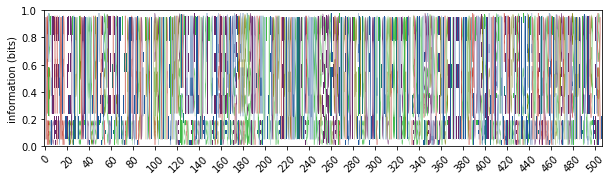

```python
# Create a sequence logo using the probability DataFrame
# Designate the color scheme, vpad, and width
# Define the global variable ww_logo
ww_logo = logomaker.Logo(alignmentSiteFreqDF,
                         color_scheme='NajafabadiEtAl2017',
                         vpad=.1,
                         width=1)

# style using Logo methods
ww_logo.style_xticks(anchor=0, spacing=20, rotation=45)

# style using Axes methods
ww_logo.ax.set_ylabel('information (bits)')
ww_logo.ax.set_xlim([-1, len(alignmentSiteFreqDF)])
```

### The Problem:

A Logo Sequence of the entire gene sequence is not very helpful, as it is too condensed to clearly see each letter. Therefore, I hoped to find a portion of the sequence to focus on so that I could create a sequence logo for a smaller portion of the gene.

### Finding a Portion to Focus on:

I uploaded my alignment to the NCBI Alignment Maker in order to easily visualize the differences in amino acids between the 5 sequences. I first checked how similar the mouse (mus musculus) was to each of the other organisms. This confirmed my previous calculation for the Human and Mouse sequence identity. I also found that the Mouse had extremely high identity compared to the Rat (image 1). Therefore, any differences between the Mouse and Human amino acid sequence were usually also present between the Rat and Human sequences.

#### Image 1

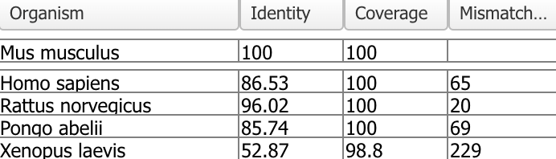

I next checked how similar the human (homo sapien) was to each of the other organisms. I found that the human had extremely high identity compared to the orangutan (image 2). Therefore, any differences between the Human and Mouse amino acid sequence were usually also present when comparing the Oranguatan and Mouse sequence.

#### Image 2

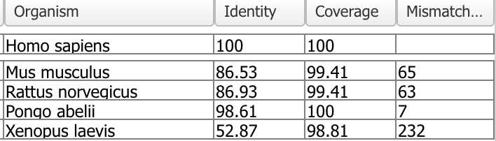

#### Image 3

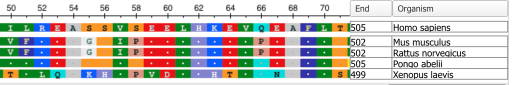

I then checked what important regions on the Homo Sapien FTO gene lie between location 50 and 70. I found a Beta-Strand region from 49 to 52 (Image 4) and a Helical Region from 59 to 74 (Image 5).

#### Image 4

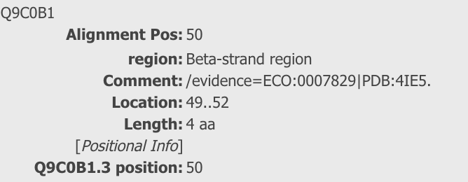

#### Image 5

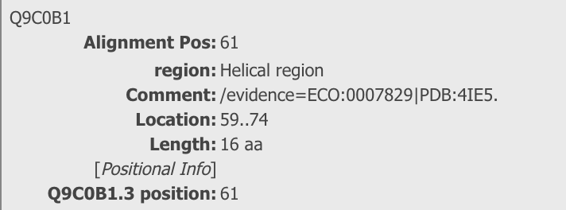

I then created a logo sequence of this portion of the FTO gene and highlighted the positions where the Human and Mouse differed.

```python
# Create a new alignment using all 5 organsisms
# Subset the previous alignment to only focus on amino acids from position 50 to 72
# These positions match image 3
# Define the global variable Varying
Varying = alignment[:,49:71]
# Print subset of alignment to check
print(Varying)
```

```
Alignment with 5 rows and 22 columns
ILREASSVSEELHKEVQEAFLT Q9C0B1
VFREAGSIPEELHKEVPEAFLT Q8BGW1
VFREAGSIPEELHKEVPEAFLT Q2A121
ILREASSVSEELHKEVQEAFLT Q5R7X0
TLLQAKHVPVDLHHTVQNAFLS Q68F54
```

```python
# Create a DataFrame containing counts of each amino acid at each position
# Define the global variable VaryingSiteCompDF
VaryingSiteCompDF = alnSiteCompositionDF(Varying)
# Print DataFrame to check
VaryingSiteCompDF
```

|  | A | C | D | E | F | G | H | I | K | L | M | N | P | Q | R | S | T | V | W | Y |
| --- | --- | --- | --- | --- | --- | --- | --- | --- | --- | --- | --- | --- | --- | --- | --- | --- | --- | --- | --- | --- |
| 0 | 0 | 0 | 0 | 0 | 0 | 0 | 0 | 2 | 0 | 0 | 0 | 0 | 0 | 0 | 0 | 0 | 1 | 2 | 0 | 0 |
| 1 | 0 | 0 | 0 | 0 | 2 | 0 | 0 | 0 | 0 | 3 | 0 | 0 | 0 | 0 | 0 | 0 | 0 | 0 | 0 | 0 |
| 2 | 0 | 0 | 0 | 0 | 0 | 0 | 0 | 0 | 0 | 1 | 0 | 0 | 0 | 0 | 4 | 0 | 0 | 0 | 0 | 0 |
| 3 | 0 | 0 | 0 | 4 | 0 | 0 | 0 | 0 | 0 | 0 | 0 | 0 | 0 | 1 | 0 | 0 | 0 | 0 | 0 | 0 |
| 4 | 5 | 0 | 0 | 0 | 0 | 0 | 0 | 0 | 0 | 0 | 0 | 0 | 0 | 0 | 0 | 0 | 0 | 0 | 0 | 0 |
| 5 | 0 | 0 | 0 | 0 | 0 | 2 | 0 | 0 | 1 | 0 | 0 | 0 | 0 | 0 | 0 | 2 | 0 | 0 | 0 | 0 |
| 6 | 0 | 0 | 0 | 0 | 0 | 0 | 1 | 0 | 0 | 0 | 0 | 0 | 0 | 0 | 0 | 4 | 0 | 0 | 0 | 0 |
| 7 | 0 | 0 | 0 | 0 | 0 | 0 | 0 | 2 | 0 | 0 | 0 | 0 | 0 | 0 | 0 | 0 | 0 | 3 | 0 | 0 |
| 8 | 0 | 0 | 0 | 0 | 0 | 0 | 0 | 0 | 0 | 0 | 0 | 0 | 3 | 0 | 0 | 2 | 0 | 0 | 0 | 0 |
| 9 | 0 | 0 | 0 | 4 | 0 | 0 | 0 | 0 | 0 | 0 | 0 | 0 | 0 | 0 | 0 | 0 | 0 | 1 | 0 | 0 |
| 10 | 0 | 0 | 1 | 4 | 0 | 0 | 0 | 0 | 0 | 0 | 0 | 0 | 0 | 0 | 0 | 0 | 0 | 0 | 0 | 0 |
| 11 | 0 | 0 | 0 | 0 | 0 | 0 | 0 | 0 | 0 | 5 | 0 | 0 | 0 | 0 | 0 | 0 | 0 | 0 | 0 | 0 |
| 12 | 0 | 0 | 0 | 0 | 0 | 0 | 5 | 0 | 0 | 0 | 0 | 0 | 0 | 0 | 0 | 0 | 0 | 0 | 0 | 0 |
| 13 | 0 | 0 | 0 | 0 | 0 | 0 | 1 | 0 | 4 | 0 | 0 | 0 | 0 | 0 | 0 | 0 | 0 | 0 | 0 | 0 |
| 14 | 0 | 0 | 0 | 4 | 0 | 0 | 0 | 0 | 0 | 0 | 0 | 0 | 0 | 0 | 0 | 0 | 1 | 0 | 0 | 0 |
| 15 | 0 | 0 | 0 | 0 | 0 | 0 | 0 | 0 | 0 | 0 | 0 | 0 | 0 | 0 | 0 | 0 | 0 | 5 | 0 | 0 |
| 16 | 0 | 0 | 0 | 0 | 0 | 0 | 0 | 0 | 0 | 0 | 0 | 0 | 2 | 3 | 0 | 0 | 0 | 0 | 0 | 0 |
| 17 | 0 | 0 | 0 | 4 | 0 | 0 | 0 | 0 | 0 | 0 | 0 | 1 | 0 | 0 | 0 | 0 | 0 | 0 | 0 | 0 |
| 18 | 5 | 0 | 0 | 0 | 0 | 0 | 0 | 0 | 0 | 0 | 0 | 0 | 0 | 0 | 0 | 0 | 0 | 0 | 0 | 0 |
| 19 | 0 | 0 | 0 | 0 | 5 | 0 | 0 | 0 | 0 | 0 | 0 | 0 | 0 | 0 | 0 | 0 | 0 | 0 | 0 | 0 |
| 20 | 0 | 0 | 0 | 0 | 0 | 0 | 0 | 0 | 0 | 5 | 0 | 0 | 0 | 0 | 0 | 0 | 0 | 0 | 0 | 0 |
| 21 | 0 | 0 | 0 | 0 | 0 | 0 | 0 | 0 | 0 | 0 | 0 | 0 | 0 | 0 | 0 | 1 | 4 | 0 | 0 | 0 |

```python
# Convert the counts from the Data Frame to relative probabilities
# A 1.0 indicates that all 5 sequences have the designated amino acid at that position.
# Define the global variable VaryingSiteFreqDF
VaryingFreqDF = VaryingSiteCompDF.div(VaryingSiteCompDF.sum(axis=1), axis=0)
# Print DataFrame to check
VaryingFreqDF
```

|  | A | C | D | E | F | G | H | I | K | L | M | N | P | Q | R | S | T | V | W | Y |
| --- | --- | --- | --- | --- | --- | --- | --- | --- | --- | --- | --- | --- | --- | --- | --- | --- | --- | --- | --- | --- |
| 0 | 0.0 | 0.0 | 0.0 | 0.0 | 0.0 | 0.0 | 0.0 | 0.4 | 0.0 | 0.0 | 0.0 | 0.0 | 0.0 | 0.0 | 0.0 | 0.0 | 0.2 | 0.4 | 0.0 | 0.0 |
| 1 | 0.0 | 0.0 | 0.0 | 0.0 | 0.4 | 0.0 | 0.0 | 0.0 | 0.0 | 0.6 | 0.0 | 0.0 | 0.0 | 0.0 | 0.0 | 0.0 | 0.0 | 0.0 | 0.0 | 0.0 |
| 2 | 0.0 | 0.0 | 0.0 | 0.0 | 0.0 | 0.0 | 0.0 | 0.0 | 0.0 | 0.2 | 0.0 | 0.0 | 0.0 | 0.0 | 0.8 | 0.0 | 0.0 | 0.0 | 0.0 | 0.0 |
| 3 | 0.0 | 0.0 | 0.0 | 0.8 | 0.0 | 0.0 | 0.0 | 0.0 | 0.0 | 0.0 | 0.0 | 0.0 | 0.0 | 0.2 | 0.0 | 0.0 | 0.0 | 0.0 | 0.0 | 0.0 |
| 4 | 1.0 | 0.0 | 0.0 | 0.0 | 0.0 | 0.0 | 0.0 | 0.0 | 0.0 | 0.0 | 0.0 | 0.0 | 0.0 | 0.0 | 0.0 | 0.0 | 0.0 | 0.0 | 0.0 | 0.0 |
| 5 | 0.0 | 0.0 | 0.0 | 0.0 | 0.0 | 0.4 | 0.0 | 0.0 | 0.2 | 0.0 | 0.0 | 0.0 | 0.0 | 0.0 | 0.0 | 0.4 | 0.0 | 0.0 | 0.0 | 0.0 |
| 6 | 0.0 | 0.0 | 0.0 | 0.0 | 0.0 | 0.0 | 0.2 | 0.0 | 0.0 | 0.0 | 0.0 | 0.0 | 0.0 | 0.0 | 0.0 | 0.8 | 0.0 | 0.0 | 0.0 | 0.0 |
| 7 | 0.0 | 0.0 | 0.0 | 0.0 | 0.0 | 0.0 | 0.0 | 0.4 | 0.0 | 0.0 | 0.0 | 0.0 | 0.0 | 0.0 | 0.0 | 0.0 | 0.0 | 0.6 | 0.0 | 0.0 |
| 8 | 0.0 | 0.0 | 0.0 | 0.0 | 0.0 | 0.0 | 0.0 | 0.0 | 0.0 | 0.0 | 0.0 | 0.0 | 0.6 | 0.0 | 0.0 | 0.4 | 0.0 | 0.0 | 0.0 | 0.0 |
| 9 | 0.0 | 0.0 | 0.0 | 0.8 | 0.0 | 0.0 | 0.0 | 0.0 | 0.0 | 0.0 | 0.0 | 0.0 | 0.0 | 0.0 | 0.0 | 0.0 | 0.0 | 0.2 | 0.0 | 0.0 |
| 10 | 0.0 | 0.0 | 0.2 | 0.8 | 0.0 | 0.0 | 0.0 | 0.0 | 0.0 | 0.0 | 0.0 | 0.0 | 0.0 | 0.0 | 0.0 | 0.0 | 0.0 | 0.0 | 0.0 | 0.0 |
| 11 | 0.0 | 0.0 | 0.0 | 0.0 | 0.0 | 0.0 | 0.0 | 0.0 | 0.0 | 1.0 | 0.0 | 0.0 | 0.0 | 0.0 | 0.0 | 0.0 | 0.0 | 0.0 | 0.0 | 0.0 |
| 12 | 0.0 | 0.0 | 0.0 | 0.0 | 0.0 | 0.0 | 1.0 | 0.0 | 0.0 | 0.0 | 0.0 | 0.0 | 0.0 | 0.0 | 0.0 | 0.0 | 0.0 | 0.0 | 0.0 | 0.0 |
| 13 | 0.0 | 0.0 | 0.0 | 0.0 | 0.0 | 0.0 | 0.2 | 0.0 | 0.8 | 0.0 | 0.0 | 0.0 | 0.0 | 0.0 | 0.0 | 0.0 | 0.0 | 0.0 | 0.0 | 0.0 |
| 14 | 0.0 | 0.0 | 0.0 | 0.8 | 0.0 | 0.0 | 0.0 | 0.0 | 0.0 | 0.0 | 0.0 | 0.0 | 0.0 | 0.0 | 0.0 | 0.0 | 0.2 | 0.0 | 0.0 | 0.0 |
| 15 | 0.0 | 0.0 | 0.0 | 0.0 | 0.0 | 0.0 | 0.0 | 0.0 | 0.0 | 0.0 | 0.0 | 0.0 | 0.0 | 0.0 | 0.0 | 0.0 | 0.0 | 1.0 | 0.0 | 0.0 |
| 16 | 0.0 | 0.0 | 0.0 | 0.0 | 0.0 | 0.0 | 0.0 | 0.0 | 0.0 | 0.0 | 0.0 | 0.0 | 0.4 | 0.6 | 0.0 | 0.0 | 0.0 | 0.0 | 0.0 | 0.0 |
| 17 | 0.0 | 0.0 | 0.0 | 0.8 | 0.0 | 0.0 | 0.0 | 0.0 | 0.0 | 0.0 | 0.0 | 0.2 | 0.0 | 0.0 | 0.0 | 0.0 | 0.0 | 0.0 | 0.0 | 0.0 |
| 18 | 1.0 | 0.0 | 0.0 | 0.0 | 0.0 | 0.0 | 0.0 | 0.0 | 0.0 | 0.0 | 0.0 | 0.0 | 0.0 | 0.0 | 0.0 | 0.0 | 0.0 | 0.0 | 0.0 | 0.0 |
| 19 | 0.0 | 0.0 | 0.0 | 0.0 | 1.0 | 0.0 | 0.0 | 0.0 | 0.0 | 0.0 | 0.0 | 0.0 | 0.0 | 0.0 | 0.0 | 0.0 | 0.0 | 0.0 | 0.0 | 0.0 |
| 20 | 0.0 | 0.0 | 0.0 | 0.0 | 0.0 | 0.0 | 0.0 | 0.0 | 0.0 | 1.0 | 0.0 | 0.0 | 0.0 | 0.0 | 0.0 | 0.0 | 0.0 | 0.0 | 0.0 | 0.0 |
| 21 | 0.0 | 0.0 | 0.0 | 0.0 | 0.0 | 0.0 | 0.0 | 0.0 | 0.0 | 0.0 | 0.0 | 0.0 | 0.0 | 0.0 | 0.0 | 0.2 | 0.8 | 0.0 | 0.0 | 0.0 |

```
(-1.0, 22.0)
```

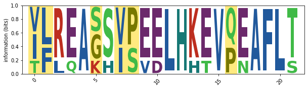

```python
# Create a sequence logo of the small portion of the alignment using LogoMaker
# Input the Frequency dataframe created above
# Define the global variable ww_logo
ww_logo = logomaker.Logo(VaryingFreqDF,
                         color_scheme='NajafabadiEtAl2017',
                         vpad=.1,
                         width=.8)

# style using Logo methods
ww_logo.style_xticks(anchor=0, spacing=5, rotation=45)
# Highlight positions where Human and Mouse differed
ww_logo.highlight_position(p=0, color='gold', alpha=.5)
ww_logo.highlight_position(p=1, color='gold', alpha=.5)
ww_logo.highlight_position(p=5, color='gold', alpha=.5)
ww_logo.highlight_position(p=7, color='gold', alpha=.5)
ww_logo.highlight_position(p=8, color='gold', alpha=.5)
ww_logo.highlight_position(p=16, color='gold', alpha=.5)

# style using Axes methods
ww_logo.ax.set_ylabel('information (bits)')
ww_logo.ax.set_xlim([-1, len(VaryingFreqDF)])
```

## Analyzing Protein Structure

### Bioinformatics Method: Homology Modeling

Now that I have examined the sequence, I set out to examine the protein structure. Since the protein structure for the Human FTO gene is readily available and has a PDB ID, viewing its structure is relatively easy using python's NGL View. Unfortunately, the Mouse FTO gene does not have a experimentally derived structure. Therefore, I will be using SWISS homology modeling as my bioinformatics method.

In order to perform homology modeling using a user template, I input the Human 4IDZ PDB as the template file and the Mouse FTO sequence from UniProt as the target sequence. Homology modeling is able to compare these two sequences and create a predicted model for the mouse protein based on the 4IDZ protein. It can guess how the proteins will be different based on the differences in the amino acid sequence. Its output is a PDB file which I examined in PyMol.

First, I loaded in the Homo Sapien FTO protein.

```python
# PROTEIN STRUCTURE: Human PDB
# Use NGL View to show the structure based on the pdb ID
# Define the global variable view
view = nglview.show_pdbid("4IDZ")
view.add_representation('licorice', selection='chain A')
view
```

Next, I used created a model using SWISS. Below is this Ramachandran Plot, which shows the statistical distribution of the combinations of the backbone dihedral angles ϕ and ψ. Only 1.46% of the amino acids were considered outliers. Additionally the QMEANDisCo Global Score was 0.82. Therefore, I would consider the model to be of good quality.

#### Image 6

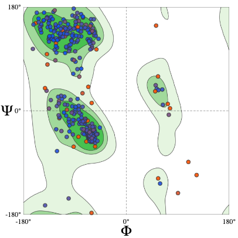

Here is a video of the Mouse FTO Model and the Human 4IDZ protein overlayed on top of each other.

```python
YouTubeVideo('8CHTRbWYkrw', width=500, height=300)
```

[video not shown]

The 4IDZ protein is in red and the Mouse Homology Model is in Green. From this video, we can see that the proteins almost perfectly overlay on top of one another. I did zoom in on 2 different smoothed loops that were only present in the Mouse Model. However, all helix ribbons and strand arrows appear to be identical between the two proteins.

### Analysis Method: 3D Protein Measurements

For my analysis method, I decided to perform 3D protein measurements. The input is a PDB file, which we now have for the mouse model due to homology modeling. The output is a certain measurement depending on what is called for. I will measure the distance between alpha carbons in each protein and the angle between the first 3 atoms.

```python
# Retrieve the structure of the Human FTO model: 4IDZ
# Define the global variables parser and stucture
parser = PDBParser()
structure = parser.get_structure("4IDZ", "4idz.pdb")
# Set residues variable to get residues from the structure
# Define the global variable residues
residues = [r for r in structure.get_residues()]
# Calculate the distance between the alpha carbons for a pair of residues
# Define the global variables one and two
one  = residues[0]["CA"].get_coord()
two = residues[1]["CA"].get_coord()
# Subtract the coordinates to get the distance
print('{} - {} = {}'.format(one,two, np.linalg.norm(one-two)))

# Calculate the angle between the first 3 atoms
# Set atom variable to get atoms in structure
# Define the global variables atom, vector1, vector2, vector3, and angle
atom = [a for a in structure.get_atoms()]
vector1 = atom[0].get_vector()
vector2 = atom[1].get_vector()
vector3 = atom[2].get_vector()
angle = Bio.PDB.vectors.calc_angle(vector1, vector2, vector3)
# Print the angle
print(angle)
```

```
[ 46.068  13.532 -31.037] - [ 43.496  10.996 -29.84 ] = 3.8051674365997314
1.9275740803421897
```

```python
# Retrieve the structure of the mouse FTO model made using SWISS
# Define the global variables parser and structure
parser = PDBParser()
structure = parser.get_structure("Mouse", "model_01.pdb")
# Set residues variable to get residues from the structure
# Define the global variable residues
residues = [r for r in structure.get_residues()]
# Calculate the distance between the alpha carbons for a pair of residues
# Define the global variables one and two
one  = residues[0]["CA"].get_coord()
two = residues[1]["CA"].get_coord()
# Subtract the coordinates to get the distance
print('{} - {} = {}'.format(one,two, np.linalg.norm(one-two)))

# Calculate the angle between the first 3 atoms
# Set atom variable to get atoms in structure
# Define the global variables atom, vector1, vector2, vector3, and angle
atom = [a for a in structure.get_atoms()]
vector1 = atom[0].get_vector()
vector2 = atom[1].get_vector()
vector3 = atom[2].get_vector()
angle = Bio.PDB.vectors.calc_angle(vector1, vector2, vector3)
#Print the angle
print(angle)
```

```
[ 43.479   7.635 -23.59 ] - [ 44.033   7.711 -19.813] = 3.8181703090667725
1.9179173451279627
```

```python
# Percent Change in value = change in value / original (Human) value
# Percent Change for distance between alpha carbons
# Define global variables PC_distance and PC_angle
PC_distance = (3.8181703090667725-3.8051674365997314)/3.8051674365997314
print(PC_distance)

# Percent Change for angle between atoms
PC_angle = (1.9179173451279627-1.9275740803421897)/1.9275740803421897
print(PC_angle)
```

```
0.0034171617106710773
-0.00500978681582637
```

There is a 0.3% change in the distance between the alpha carbons when comparing the Mouse PDB against the Human PDB. There is a 0.5% change in the angle between the first three atoms when comparing the Mouse PDB against the Human PDB.

# Analysis of Results

### Conclusions regarding sequence

Based on sequence alone, the Mus Musculus FTO gene does appear to be representative of the Homo Sapien gene. Therefore, the Mus Musculus is a good model organism for research on the Homo Sapien FTO gene.

My hypothesis stated that if the percent identity was above 70%, then the Mus Musculus would be a good model for analyzing the effects of FTO on homo sapiens. After performing a sequence alignment and performing calculations, it was found that percent identity between the two organisms FTO gene is over 86%. In order to ensure that mismatches were not in highly conserved portions of the FTO gene, I created a sequence logo of a portion of the FTO gene where percent identity was low between the two organisms specifically. We see that between all 5 organisms, there is some variation at these positions. Therefore, these don't appear to be highly conserved portions of the gene, and are likely not causing major differences between the Homo Sapien and Mus Musculus.

### Conclusions regarding protein structure

Based on protein visualization and calculations, the Mus Musculus FTO protein appears to be very similar to the Homo Sapien FTO protein. Based on the structure overlay and the measurements, I would consider these proteins to be > 70% similar. Therefore, the Mus Musculus is a good model organism for research on the Homo Sapien FTO gene.

After creating a Model for the Mouse FTO protein, I overlaid the two proteins on top of one another in PyMol. We can see from the video that the differences between the two are minor. 2 smoothed loops were only present in the Mouse Model. However, all helix ribbons and strand arrows appear to be identical between the two proteins. After performing 3D protein measurements, we found that there is a 0.3% change in the distance between the alpha carbons when comparing the Mouse PDB against the Human PDB. There is a 0.5% change in the angle between the first three atoms when comparing the Mouse PDB against the Human PDB.

All in all, these two protein structures are extremely similar and the small changes that are present are probably not causing a big enough difference to have an effect on how the protien functions in each organism.